# Data 624 - Homework #1

Paul Britton

Please submit exercises 2.1, 2.2, 2.3 and 2.6 from the Hyndman online Forecasting book. Please submit both your Rpubs link as well as attach the .rmd file with your code.

```r
rm(list = ls())
library(forecast)
library(readxl)
library(RCurl)
library(fpp2)
```

## Question 2.1

```r
describe.data <- function(data) {
  freq <- frequency(data)
  outlier <- which.max(data)
  return(c(freq,outlier))
}
```

### Gold

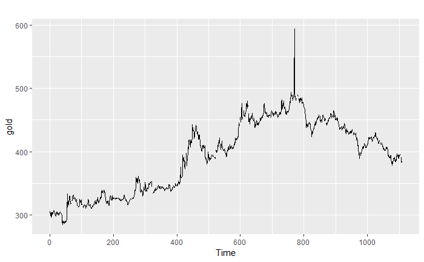

```r
help(gold)
autoplot(gold)
```

```r
question1 <- describe.data(gold)
```

- The “gold” data represents the daily (morning) gold price in USD for the period 1985-01-01 to 1989-03-31.
- The frequency of this data is 1. The data is daily.
- The outlier datapoint appears at index 770 and corresponds to a price of 593.7

### Wollyrnq

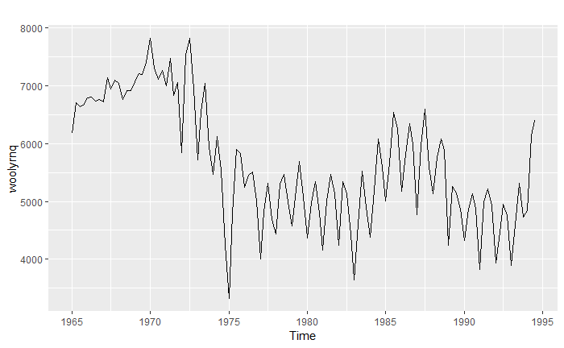

```r
help(woolyrnq)
autoplot(woolyrnq)
```

```r
question2 <- describe.data(woolyrnq)
```

- The “woolyrnq” data represents the quarterly production of woolen yard (tonnes) in Australia for the period Mar-1965 to Sep-1994
- The frequency of this data is 4 observation per year, i.e. quarterly.

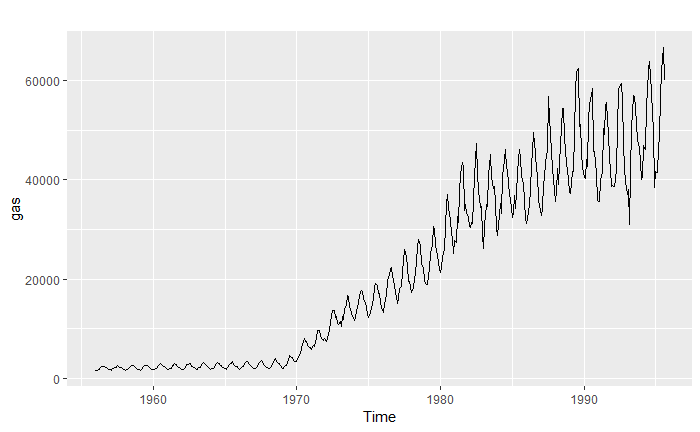

```r
help(gas)
autoplot(gas)
```

```r
question3 <- describe.data(gas)
```

## Question 2.2

### A

```r
tute1 <- read.csv("http://otexts.com/fpp2/extrafiles/tute1.csv",header=T)
View(tute1)
```

### B

```r
mytimeseries <- ts(tute1[,-1], start=1981, frequency=4)
```

### C

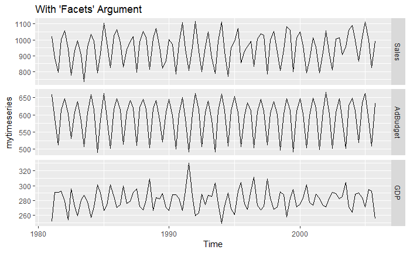

```r
autoplot(mytimeseries, facets=TRUE,main="With 'Facets' Argument")
```

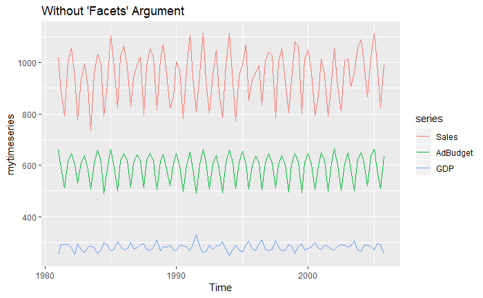

```r
autoplot(mytimeseries,main="Without 'Facets' Argument")
```

```r
NA
NA
```

## Question 2.3

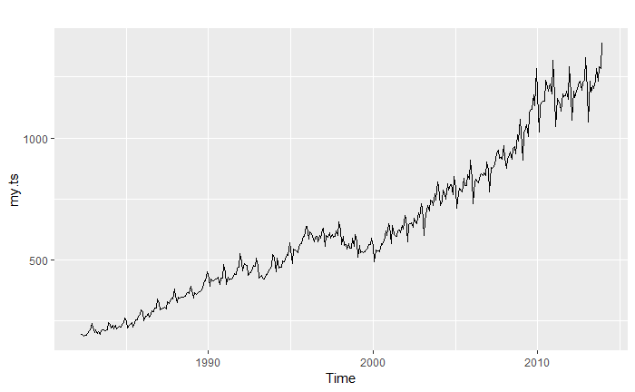

```r
retaildata <- readxl::read_excel("C:/Users/Paul/OneDrive - CUNY School of Professional Studies/CUNY/DATA 624/retail.xlsx", skip=1)

my.ts <- ts(retaildata[,"A3349388W"],
  frequency=12, start=c(1982,4))

autoplot(my.ts)
```

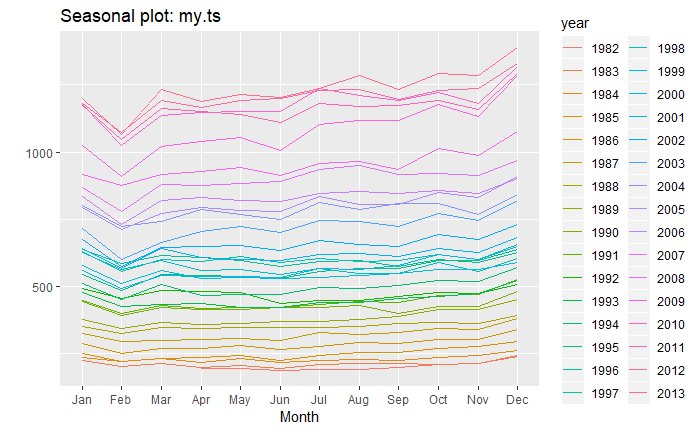

```r
ggseasonplot(my.ts)
```

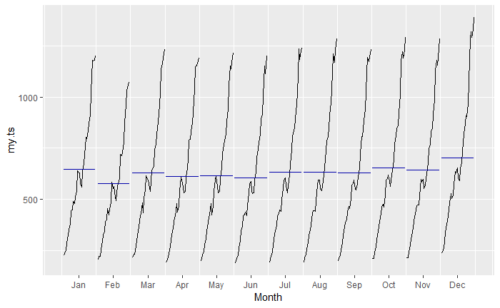

```r
ggsubseriesplot(my.ts)
```

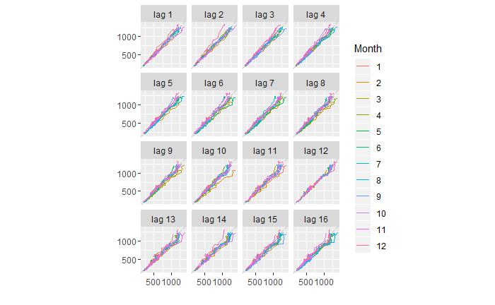

```r
gglagplot(my.ts)
```

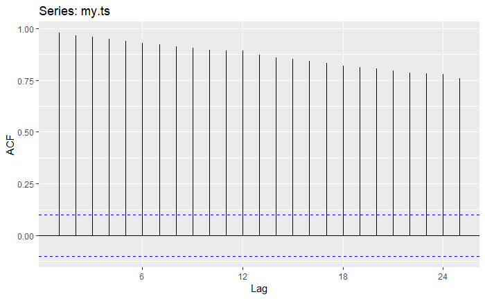

```r
ggAcf(my.ts)
```

```r
NA
NA
```

For this question I just picked a column at random and ended up with “Turnover ; Total (State) ; Takeaway food services ;”.

- As per the timeseries plot, there is a clear upward sloping trend in the data and there are definately some seasonal / cyclical effects apparent
- The seasonaly plot shows a few things: a consistent dip in Feb, a rise towards the end of of the year. The same is present in the sub-season plot.
- The lag plots are difficult to look at “as is” because the seasonal effects are likely weak. I wonder whether it would make more sense to difference the timeseries before applying this plotting function
- The ACF plot shows a high degree of auto-correlation with low decay.

## Question 2.6

Use the following graphics functions: autoplot(), ggseasonplot(), ggsubseriesplot(), gglagplot(), ggAcf() and explore features from the following time series: hsales, usdeaths, bricksq, sunspotarea, gasoline.

Can you spot any seasonality, cyclicity and trend? What do you learn about the series?

### hsales

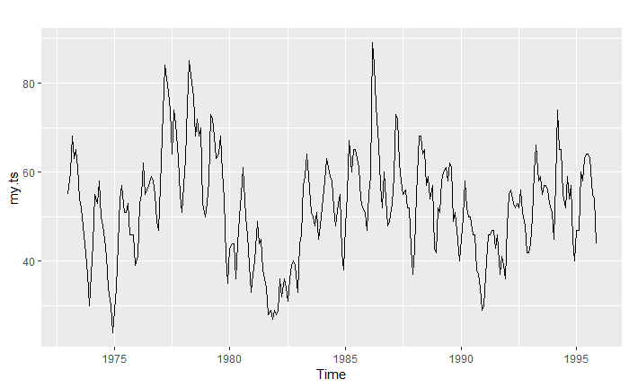

```r
my.ts <- hsales

autoplot(my.ts)
```

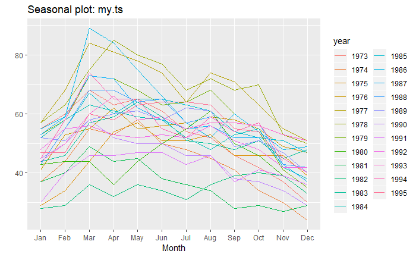

```r
ggseasonplot(my.ts)
```

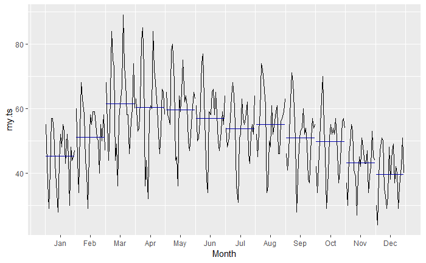

```r
ggsubseriesplot(my.ts)
```

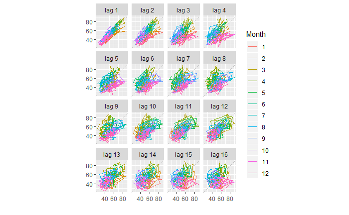

```r
gglagplot(my.ts)
```

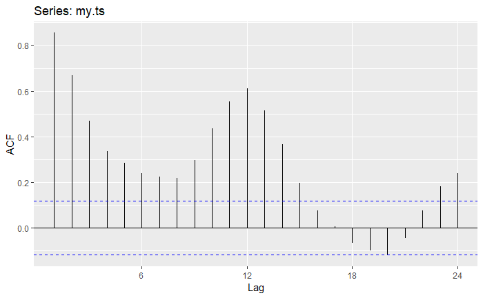

```r
ggAcf(my.ts)
```

### usdeaths

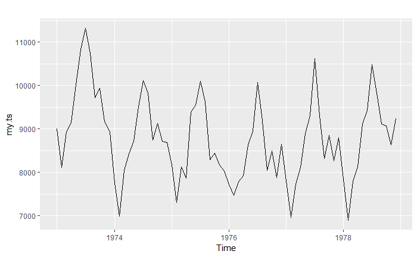

```r
my.ts <- usdeaths

autoplot(my.ts)
```

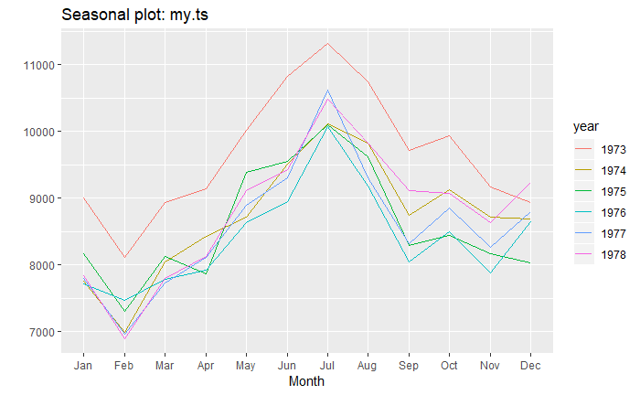

```r
ggseasonplot(my.ts)
```

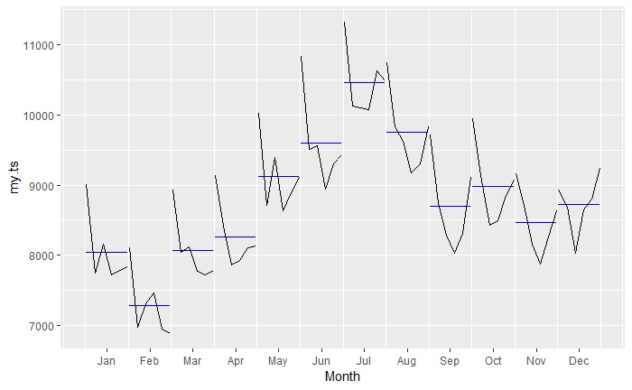

```r
ggsubseriesplot(my.ts)
```

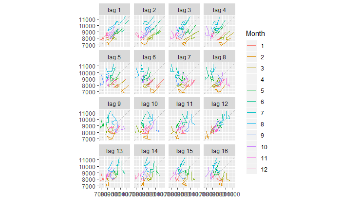

```r
gglagplot(my.ts)
```

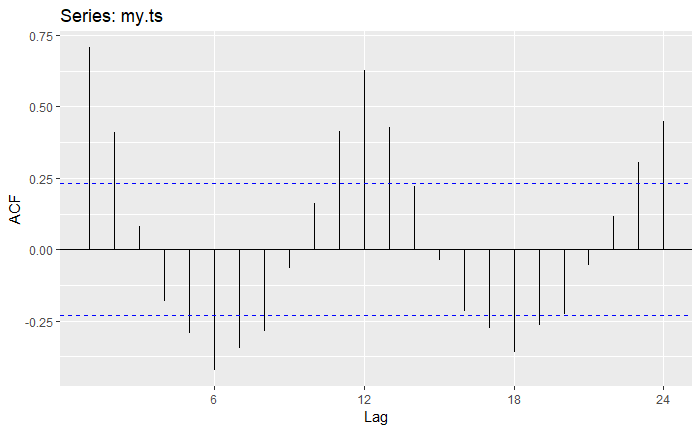

```r
ggAcf(my.ts)
```

### bricksq

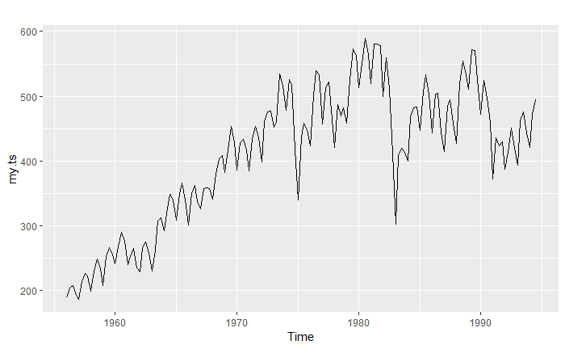

```r
my.ts <- bricksq

autoplot(my.ts)
```

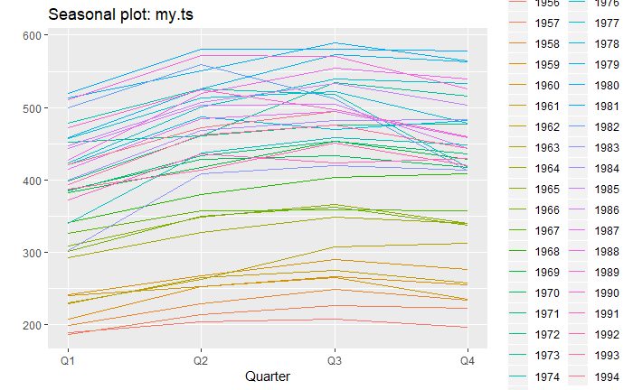

```r
ggseasonplot(my.ts)
```

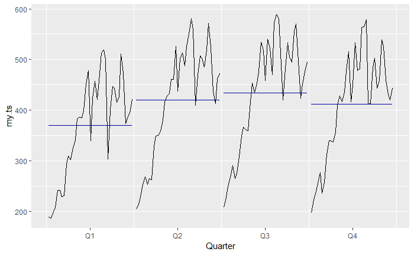

```r
ggsubseriesplot(my.ts)
```

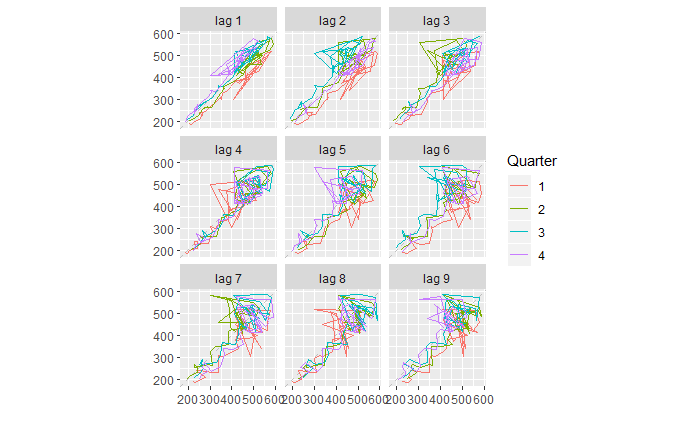

```r
gglagplot(my.ts)
```

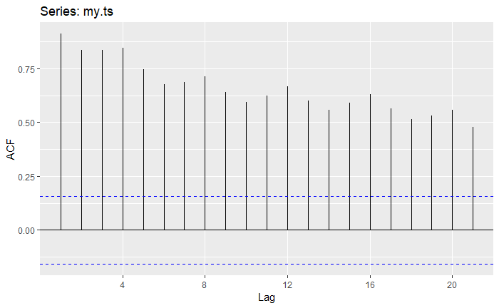

```r
ggAcf(my.ts)
```

### sunspotarea

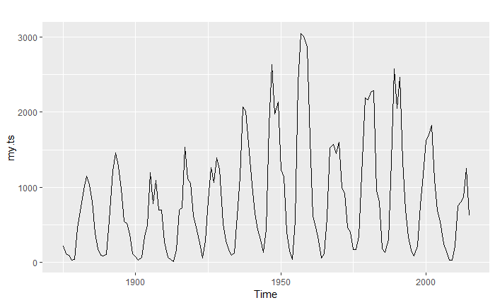

```r
my.ts <-  sunspotarea

autoplot(my.ts)
```

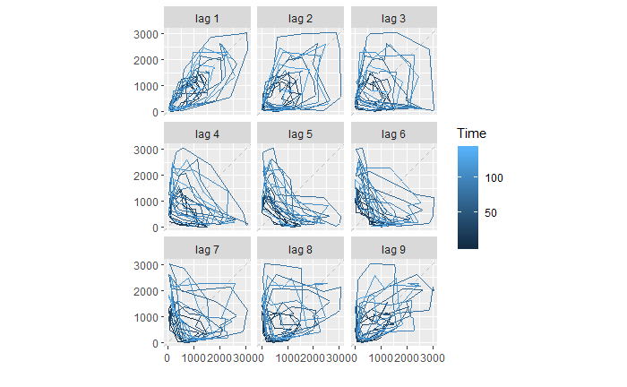

```r
#ggseasonplot(my.ts)
#ggsubseriesplot(my.ts)
gglagplot(my.ts)
```

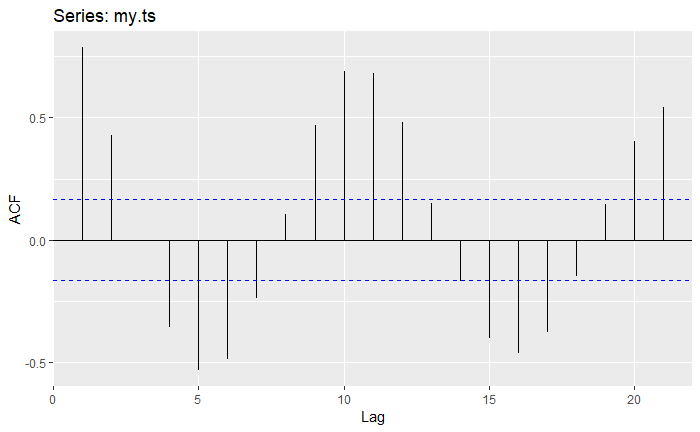

```r
ggAcf(my.ts)
```

```r
View(my.ts)
```

### gasoline

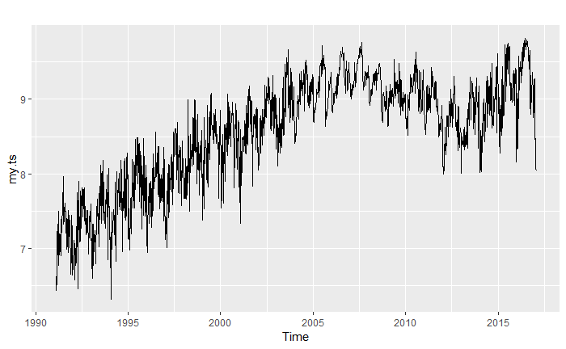

```r
my.ts <-  gasoline

autoplot(my.ts)
```

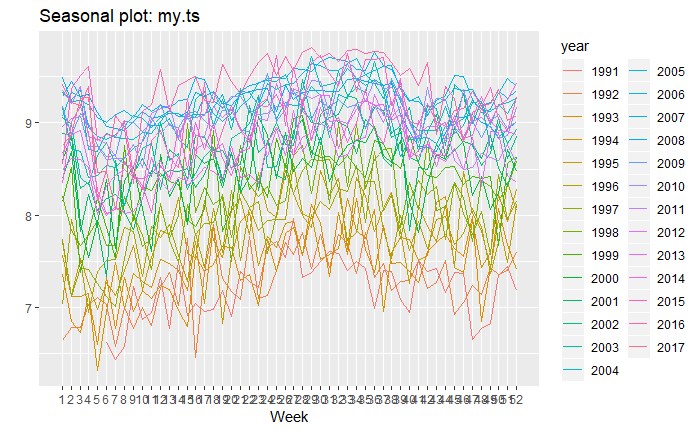

```r
ggseasonplot(my.ts)
```

```r
ggsubseriesplot(my.ts)
```

[output not shown]